# Milestone 1: Exploratory Data Analysis

**FEMA Individuals & Households Program (IHP) registrations, Hurricane Ian (DR-4673), Lee County, FL**

CAI 4105 Machine Learning, Fall 2026. This notebook covers the *Data Understanding* phase (CRISP-DM): what the data is, how good it is, what it says, and what could go wrong.

**How to run:** put `ihp_dr4673_lee.csv` in the same folder as this notebook, then Kernel → *Restart & Run All*. The notebook needs only pandas, numpy, matplotlib, seaborn, and scipy. Every chart is also saved to a `figures/` folder next to the notebook.

> **Scope note:** the team repository also contains `src/utils/columns.py` and `docs/data_dictionary.md`, which define the column roles and document the dataset. They are not part of the Milestone 1 submission. This notebook runs from the CSV alone.

**Reading guide:** each section has a plain-English note above the code saying *what we are checking and why it matters*.

> *AI-use disclosure:* this notebook was first drafted with Claude Code and then checked, revised, and reviewed by the team. See `docs/AI_USAGE.md`.

```python
import numpy as np
import pandas as pd
import matplotlib.pyplot as plt
import seaborn as sns
from pathlib import Path
from matplotlib.colors import LinearSegmentedColormap
from matplotlib.patches import Patch
from scipy.stats import chi2_contingency

CSV_NAME = "ihp_dr4673_lee.csv"
CSV_CANDIDATES = [Path(CSV_NAME), Path("../../data/raw") / CSV_NAME, Path("data/raw") / CSV_NAME]


def load_data():
    for path in CSV_CANDIDATES:
        if path.exists():
            return pd.read_csv(path, low_memory=False)
    raise FileNotFoundError(
        f"Put {CSV_NAME} in the same folder as this notebook. Looked in: {[str(p) for p in CSV_CANDIDATES]}"
    )


BLUE = "#2a78d6"      # eligible / primary series
ORANGE = "#eb6834"    # not eligible / second series
GRAY = "#898781"      # neutral / reference lines
AQUA = "#1baf7a"
INK = "#0b0b0b"
INK_SOFT = "#52514e"
GRID = "#e1e0d9"
FIG_DIR = Path("figures")


def set_style():
    plt.rcParams.update({
        "figure.figsize": (8, 4.5),
        "figure.dpi": 110,
        "savefig.dpi": 200,
        "savefig.bbox": "tight",
        "font.family": "sans-serif",
        "font.sans-serif": ["Segoe UI", "DejaVu Sans", "Arial"],
        "font.size": 10,
        "axes.titlesize": 12,
        "axes.titleweight": "bold",
        "axes.titlelocation": "left",
        "axes.labelcolor": INK_SOFT,
        "axes.edgecolor": GRID,
        "axes.grid": True,
        "axes.axisbelow": True,
        "axes.spines.top": False,
        "axes.spines.right": False,
        "grid.color": GRID,
        "grid.linewidth": 0.6,
        "xtick.color": INK_SOFT,
        "ytick.color": INK_SOFT,
        "text.color": INK,
        "legend.frameon": False,
    })


def save_fig(name):
    FIG_DIR.mkdir(parents=True, exist_ok=True)
    plt.savefig(FIG_DIR / f"{name}.png")


set_style()
pd.set_option("display.width", 160, "display.max_columns", 40, "display.max_rows", 120)
```

```python
# Column roles: which columns may be used as features (documented in Section 4)
TARGET = "ihpEligible"

ID_OR_CONSTANT = [
    "id", "lastRefresh", "declarationDate", "disasterNumber", "incidentTypeCode",
    "damagedStateAbbreviation", "county", "fips", "censusYear",
    "foundationDamage", "foundationDamageAmount", "roofDamage", "roofDamageAmount",
    "ihpMax", "onaMax",
]

LEAKAGE = [
    "ihpAmount", "haAmount", "onaAmount", "haEligible", "onaEligible", "haStatus", "haMax",
    "ihpReferral", "haReferral", "onaReferral",
    "ineligibleReason", "ineligibleInsurance", "insufficientDamage",
    "fipAmount", "sbaApproved", "tsaEligible", "tsaCheckedIn",
    "transientAccommodEligible", "transientAccommodAmount",
    "onaMedicalAssistEligible", "onaMedicalAssistAmount",
    "onaDentalAssistEligible", "onaDentalAssistAmount",
    "onaFuneralAssistEligible", "onaFuneralAssistAmount",
    "onaMovingAssistEligible", "onaMovingAssistAmount",
    "onaOtherAssistEligible", "onaOtherAssistAmount",
    "rentalAssistanceEligible", "rentalAssistanceAmount", "rentalAssistanceEndDate",
    "rentalResourceCity", "rentalResourceStateAbbrev", "rentalResourceZipCode",
    "repairAssistanceEligible", "repairAmount",
    "replacementAssistanceEligible", "replacementAmount",
    "personalPropertyEligible", "personalPropertyAmount",
    "unmetNeedRp", "unmetNeedPp",
]

APPLICATION_FEATURES = [
    "appliedDate",
    "applicantAge", "householdComposition",
    "occupantsUnderTwo", "occupants2to5", "occupants6to18", "occupants19to64", "occupants65andOver",
    "grossIncome", "ownRent", "primaryResidence", "residenceType",
    "homeOwnersInsurance", "floodInsurance", "registrationMethod",
    "damagedCity", "damagedZipCode", "censusGeoid",
    "homeDamage", "autoDamage", "reportedDamage", "selfAssessmentInformation",
    "emergencyNeeds", "foodNeed", "shelterNeed", "accessFunctionalNeeds",
]

INSPECTION_FEATURES = [
    "inspnIssued", "inspnReturned",
    "rpfvl", "ppfvl",
    "floodDamage", "floodDamageAmount", "waterLevel", "highWaterLocation",
    "destroyed", "renterDamageLevel",
    "verifiedOwnership", "verifiedOccupancy", "habitabilityRepairsRequired",
    "currentLocation",
]

# Under review: held out of both tiers until FEMA confirms when the field is populated (Section 5b).
UNDER_REVIEW = ["utilitiesOut"]

ALL_ROLES = {
    "target": [TARGET],
    "id_or_constant": ID_OR_CONSTANT,
    "leakage": LEAKAGE,
    "under_review": UNDER_REVIEW,
    "application": APPLICATION_FEATURES,
    "inspection": INSPECTION_FEATURES,
}


def role_of(column):
    for role, cols in ALL_ROLES.items():
        if column in cols:
            return role
    return "unassigned"


def check_roles(columns):
    assigned = [c for cols in ALL_ROLES.values() for c in cols]
    dupes = {c for c in assigned if assigned.count(c) > 1}
    if dupes:
        raise ValueError(f"Columns in more than one role: {sorted(dupes)}")
    unassigned = set(columns) - set(assigned)
    if unassigned:
        raise ValueError(f"Columns with no role yet: {sorted(unassigned)}")


# Cleaning: ordered survey codes become numbers; yes/no answers become 1/0; unknown stays missing.
AGE_ORDER = {"<19": 0, "19-34": 1, "35-49": 2, "50-64": 3, "65+": 4}
COUNT_ORDER = {"0": 0, "1": 1, "2": 2, "3": 3, "4": 4, "5": 5, ">5": 6}
COUNT_COLS = [
    "householdComposition", "occupantsUnderTwo", "occupants2to5",
    "occupants6to18", "occupants19to64", "occupants65andOver",
]
CATEGORICAL_COLS = [
    "grossIncome", "ownRent", "residenceType", "registrationMethod", "currentLocation",
    "selfAssessmentInformation", "damagedZipCode", "censusGeoid",
    "highWaterLocation", "renterDamageLevel",
]
LANDFALL = pd.Timestamp("2022-09-28")   # Hurricane Ian landfall, Lee County FL


def as_text(s):
    # Match on values, not Python types, so the same code works for CSV and parquet inputs.
    def f(v):
        if pd.isna(v):
            return np.nan
        if isinstance(v, (bool, np.bool_)):
            return str(bool(v))
        if isinstance(v, (int, float, np.integer, np.floating)) and float(v).is_integer():
            return str(int(v))
        return str(v).strip()
    return s.map(f)


def encode(s, mapping, name):
    t = as_text(s)
    unknown = sorted(set(t.dropna()) - set(mapping))
    if unknown:
        raise ValueError(f"{name}: unexpected values {unknown}")
    return t.map(mapping).astype("Int8")


def clean(raw, tier="inspection"):
    features = APPLICATION_FEATURES + (INSPECTION_FEATURES if tier == "inspection" else [])
    features = [c for c in features if c not in ("appliedDate", "damagedCity", "applicantAge") + tuple(COUNT_COLS)]
    df = pd.DataFrame(index=raw.index)
    df[TARGET] = encode(raw[TARGET], {"True": 1, "False": 0}, TARGET)

    applied = pd.to_datetime(raw["appliedDate"], utc=True).dt.tz_localize(None)
    df["daysSinceLandfall"] = (applied - LANDFALL).dt.days.astype("int16")
    df["applicantAge"] = encode(raw["applicantAge"], AGE_ORDER, "applicantAge")
    for c in COUNT_COLS:
        df[c] = encode(raw[c], COUNT_ORDER, c)

    for c in features:
        t = as_text(raw[c])
        present = set(t.dropna())
        if present and present <= {"True", "False"}:
            df[c] = t.map({"True": 1, "False": 0}).astype("Int8")
        elif c in CATEGORICAL_COLS:
            df[c] = raw[c].astype("category")
        else:
            df[c] = raw[c]
    return df.reset_index(drop=True)
```

## 1. The dataset

- **Source:** OpenFEMA API, dataset *Individuals and Households Program – Valid Registrations (v2)*; each row is one household's application for FEMA disaster aid.
- **Slice we use:** disaster **DR-4673 (Hurricane Ian)**, county **Lee, FL**.
- **Important caveat from FEMA:** the file contains **only *valid* registrations**. So "not eligible" here means *a valid applicant who was not awarded IHP aid*, not a fraudulent or incomplete application.
- **Quality warning from FEMA:** this is raw operational data (NEMIS) and "subject to a small percentage of human error".
- **Citation:** FEMA. *OpenFEMA Dataset: Individuals and Households Program – Valid Registrations v2.* https://www.fema.gov/openfema-data-page/individuals-and-households-program-valid-registrations-v2

```python
raw = load_data()
check_roles(raw.columns)      # every column must have a documented role (see Section 4)

applied = pd.to_datetime(raw["appliedDate"], utc=True).dt.tz_localize(None)
print(f"{raw.shape[0]:,} rows x {raw.shape[1]} columns")
print(f"Applications received {applied.min().date()} to {applied.max().date()}")
print(f"Requirement check -> rows >= 1,000: {raw.shape[0] >= 1000} | features >= 10: {len(APPLICATION_FEATURES) >= 10}")
raw.head(5).iloc[:, :10]
```

```
194,482 rows x 100 columns
Applications received 2022-09-27 to 2023-01-12
Requirement check -> rows >= 1,000: True | features >= 10: True
```

|  | incidentTypeCode | declarationDate | disasterNumber | county | fips | censusGeoid | censusYear | damagedStateAbbreviation | damagedCity | damagedZipCode |
| --- | --- | --- | --- | --- | --- | --- | --- | --- | --- | --- |
| 0 | H | 2022-09-29T00:00:00.000Z | 4673 | Lee (County) | 12071 | 120710103083 | 2020 | FL | CAPE CORAL | 33990 |
| 1 | H | 2022-09-29T00:00:00.000Z | 4673 | Lee (County) | 12071 | 120710802021 | 2020 | FL | SANIBEL | 33957 |
| 2 | H | 2022-09-29T00:00:00.000Z | 4673 | Lee (County) | 12071 | 120710602021 | 2020 | FL | FORT MYERS BEACH | 33931 |
| 3 | H | 2022-09-29T00:00:00.000Z | 4673 | Lee (County) | 12071 | 120710203013 | 2020 | FL | NORTH FORT MYERS | 33917 |
| 4 | H | 2022-09-29T00:00:00.000Z | 4673 | Lee (County) | 12071 | 120710104211 | 2020 | FL | CAPE CORAL | 33914 |

## 2. The target variable: `ihpEligible`

**Question we are answering:** *Given what we know about an applicant, will FEMA award them Individuals & Households Program aid?*

`ihpEligible = True` means the applicant received a housing (HA) and/or other-needs (ONA) award. We checked three things: is it balanced, is it clean, and what does "not eligible" actually consist of.

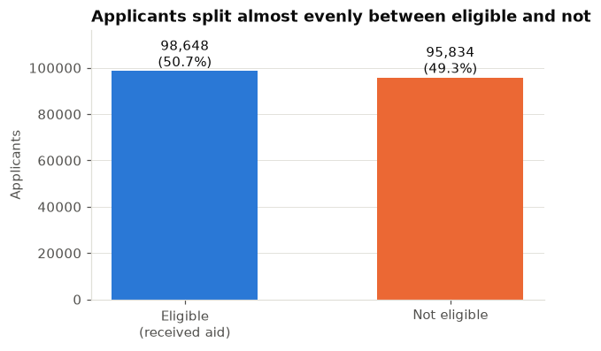

```python
counts = raw[TARGET].value_counts().reindex([True, False])
share = counts / counts.sum() * 100

fig, ax = plt.subplots(figsize=(6, 3.6))
bars = ax.bar(["Eligible\n(received aid)", "Not eligible"], counts.values, color=[BLUE, ORANGE], width=0.55)
for b, n, s in zip(bars, counts.values, share.values):
    ax.text(b.get_x() + b.get_width() / 2, n, f"{n:,}\n({s:.1f}%)", ha="center", va="bottom")
ax.set_ylim(0, counts.max() * 1.18)
ax.set_ylabel("Applicants")
ax.grid(axis="x", visible=False)
ax.set_title("Applicants split almost evenly between eligible and not")
save_fig("target_balance"); plt.show()
```

**So what:** the classes are nearly balanced (~51% / 49%), which is convenient: plain accuracy is a meaningful score, and we don't need special tricks for class imbalance.

Next, a red flag. `ihpAmount` (dollars awarded) and `ihpEligible` might be the *same information*:

```python
print(pd.crosstab(raw[TARGET], raw["ihpAmount"] > 0, rownames=["ihpEligible"], colnames=["ihpAmount > 0"]))
```

```
ihpAmount > 0  False  True
ihpEligible
False          95834      0
True               0  98648
```

**So what:** they are identical. Every eligible applicant got money, every ineligible one got $0. So `ihpAmount` can never be used to predict eligibility: it *is* eligibility. This is our first example of **data leakage**; Section 3 measures it for every column.

**Why were people ineligible?** FEMA records a high-level reason code for most (not all) ineligible applicants:

[figure not shown]

```python
REASONS = {"1": "No eligible damage or needs", "2": "Has insurance", "3": "No response / withdrew",
           "4": "Needs to submit documents", "5": "Duplicate application", "6": "Flood-zone related",
           "7": "Other", "8": "Pending", "9": "Other (unidentified)"}
inel = raw[~raw[TARGET]]
reason = inel["ineligibleReason"].map(REASONS).fillna("Never referred (no reason recorded)")
r = reason.value_counts()

fig, ax = plt.subplots(figsize=(8, 4))
ax.barh(r.index[::-1], r.values[::-1], color=ORANGE, height=0.6)
for y, v in enumerate(r.values[::-1]):
    ax.text(v, y, f" {v:,}  ({v / len(inel):.0%})", va="center", color=INK_SOFT)
ax.set_xlim(0, r.max() * 1.25); ax.grid(axis="y", visible=False)
ax.set_xlabel("Ineligible applicants")
ax.set_title("The largest group of ineligible applicants was never referred")
save_fig("ineligible_reasons"); plt.show()
```

```python
no_reason = inel["ineligibleReason"].isna().rename("no reason code")
print(pd.crosstab(no_reason, inel["ihpReferral"].fillna("missing").rename("ihpReferral")))
```

```
ihpReferral     False  True
no reason code
False               0  62158
True            33676      0
```

## 3. Leakage check: which columns give away the answer?

**Idea:** for each column, measure how strongly it is linked to eligibility, using **Cramér's V**: 0 = no link at all, 1 = the column determines eligibility exactly. No predictive model is trained. A column with a high V is almost certainly a *result* of the decision, not a cause. Constant and ID columns are skipped because they cannot be linked to anything.

```python
def as_levels(s):
    # Numbers are grouped into ten equal-count bands, with zero and missing as their own groups.
    if pd.api.types.is_numeric_dtype(s) and s.nunique() > 12:
        out = pd.Series("missing", index=s.index, dtype=object)
        out[s.notna() & (s == 0)] = "zero"
        pos = s.notna() & (s > 0)
        out[pos] = pd.qcut(s[pos], 10, duplicates="drop").astype(str)
        return out
    return s.map(lambda v: "missing" if pd.isna(v) else str(v))


def cramers_v(x, y):
    # Bias-corrected Cramér's V (Bergsma 2013), so many-category columns are not inflated.
    tab = pd.crosstab(x, y)
    chi2 = chi2_contingency(tab, correction=False)[0]
    n = tab.values.sum()
    r, k = tab.shape
    phi2 = max(0.0, chi2 / n - (k - 1) * (r - 1) / (n - 1))
    r_c = r - (r - 1) ** 2 / (n - 1)
    k_c = k - (k - 1) ** 2 / (n - 1)
    return float(np.sqrt(phi2 / min(k_c - 1, r_c - 1)))


y = raw[TARGET].astype(int)
scores = {}
for c in raw.columns:
    if c == TARGET or role_of(c) == "id_or_constant":
        continue
    levels = as_levels(raw[c])
    if levels.nunique() < 2:
        continue
    scores[c] = cramers_v(levels, y)

assoc = pd.DataFrame({"cramers_v": pd.Series(scores)})
assoc["role"] = [role_of(c) for c in assoc.index]
assoc = assoc.sort_values("cramers_v", ascending=False)
print(assoc.groupby("role")["cramers_v"].agg(["count", "max", "median"]).round(3))
```

```
              count    max  median
role
application      26  0.321   0.079
inspection       14  0.459   0.320
leakage          43  1.000   0.201
under_review      1  0.301   0.301
```

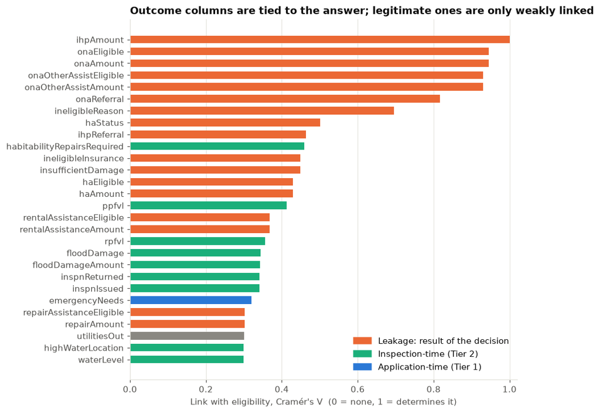

```python
top = assoc.head(28).iloc[::-1]
colors = top["role"].map({"leakage": ORANGE, "application": BLUE, "inspection": AQUA}).fillna(GRAY)

fig, ax = plt.subplots(figsize=(8, 7.5))
ax.barh(top.index, top["cramers_v"], color=colors, height=0.65)
ax.set_xlim(0, 1.02)
ax.set_xlabel("Link with eligibility, Cramér's V  (0 = none, 1 = determines it)")
ax.grid(axis="y", visible=False)
ax.legend(handles=[Patch(color=ORANGE, label="Leakage: result of the decision"),
                   Patch(color=AQUA, label="Inspection-time (Tier 2)"),
                   Patch(color=BLUE, label="Application-time (Tier 1)")], loc="lower right")
ax.set_title("Outcome columns are tied to the answer; legitimate ones are only weakly linked")
save_fig("leakage_association"); plt.show()
```

```python
assoc.loc[["ihpAmount", "onaEligible", "onaAmount", "ineligibleReason", "emergencyNeeds",
           "utilitiesOut", "foodNeed", "appliedDate", "primaryResidence", "verifiedOccupancy"]].round(2)
```

|  | cramers_v | role |
| --- | --- | --- |
| ihpAmount | 1.00 | leakage |
| onaEligible | 0.95 | leakage |
| onaAmount | 0.95 | leakage |
| ineligibleReason | 0.70 | leakage |
| emergencyNeeds | 0.32 | application |
| utilitiesOut | 0.30 | under_review |
| foodNeed | 0.27 | application |
| appliedDate | 0.27 | application |
| primaryResidence | 0.26 | application |
| verifiedOccupancy | 0.29 | inspection |

**So what:**

- Columns we labeled **leakage** sit at the top. `ihpAmount` has V = 1.00 (it is the answer), `onaEligible` and `onaAmount` are about 0.95, and `ineligibleReason` is about 0.70. Using them would only read the answer key.
- Application-time columns top out at **0.32** (`emergencyNeeds`). The strongest inspection-time column is `habitabilityRepairsRequired` at about **0.46**, and much of that comes from whether the field was answered at all (Section 5b).
- Tier 1 vs Tier 2 is the team's split: Tier 1 is known at registration, Tier 2 after inspection. Section 4 documents it. The timing comes from FEMA's field definitions; this file has no per-field timestamps to check it against.

## 4. What every column *is* (column roles)

These roles come from FEMA's data dictionary and were set before the analysis. Section 3 tests the leakage assignments against the data.

FEMA gives us 100 columns, but they are **not** all fair game as features. Many are *results* of the aid decision (dollar amounts awarded, eligibility for sub-programs, denial reasons). We sorted every column into one role (defined in the team repository's `src/utils/columns.py` and documented in `docs/data_dictionary.md`; these repository files are not part of this submission):

| Role | Meaning |
| --- | --- |
| **target** | what we predict |
| **application** | self-reported when the person registers (Tier 1 features) |
| **inspection** | only known after a FEMA inspector / verification step (Tier 2 features) |
| **under review** | held out of both tiers until FEMA confirms when the field is populated (`utilitiesOut`) |
| **leakage** | outcomes of the decision itself: using them would be cheating |
| **id_or_constant** | identifiers, or identical on every row (we filtered to one disaster + county) |

```python
roles = pd.Series({c: role_of(c) for c in raw.columns}, name="role")
print(roles.value_counts().to_string())
print("\nTier 1 (application) features:", len(APPLICATION_FEATURES), "| Tier 2 (inspection) features:", len(INSPECTION_FEATURES))
```

```
role
leakage           43
application       26
id_or_constant    15
inspection        14
target             1
under_review       1

Tier 1 (application) features: 26 | Tier 2 (inspection) features: 14
```

## 5. Data quality assessment

### 5a. Constant and identifier columns

```python
n_unique = raw.nunique(dropna=False)
constant = n_unique[n_unique == 1].index.tolist()
print(f"{len(constant)} columns have exactly one value on every row:\n  {constant}")
print(f"\n'id' is unique per row: {raw['id'].is_unique}  (an identifier, so never a feature)")
```

```
14 columns have exactly one value on every row:
  ['incidentTypeCode', 'declarationDate', 'disasterNumber', 'county', 'fips', 'censusYear', 'damagedStateAbbreviation', 'foundationDamage', 'foundationDamageAmount', 'roofDamage', 'roofDamageAmount', 'ihpMax', 'onaMax', 'lastRefresh']

'id' is unique per row: True  (an identifier, so never a feature)
```

### 5b. Missing values

Blanks may not be random: a blank can mean the question did not apply, or the answer is missing for another reason. The table after the chart compares eligibility for blank and filled answers. A large gap means the blank itself carries information.

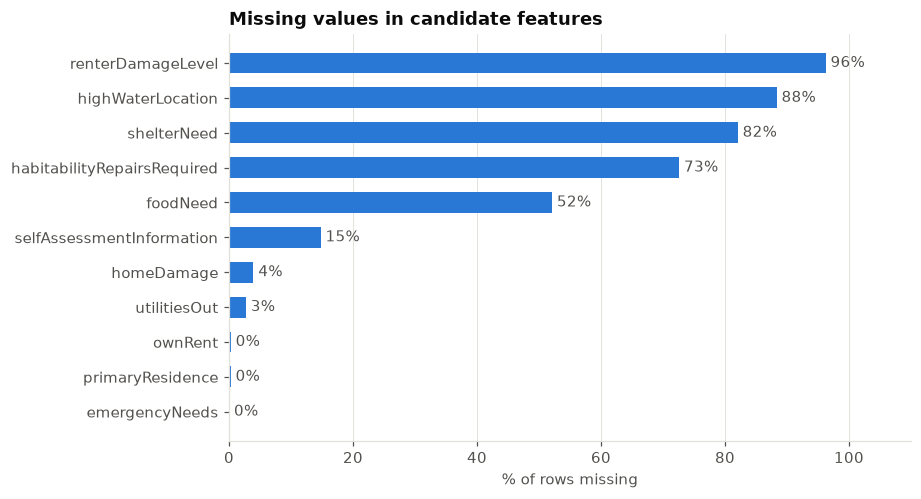

```
19 columns have any missing values; 11 of them are candidate features.
Columns >90% empty (leakage columns, excluded anyway): ['rentalResourceZipCode', 'rentalAssistanceEndDate', 'rentalResourceCity', 'rentalResourceStateAbbrev']
```

```python
miss = (raw.isna().mean() * 100).sort_values(ascending=False)
miss = miss[miss > 0]
feature_cols = APPLICATION_FEATURES + INSPECTION_FEATURES + UNDER_REVIEW
usable = miss[miss.index.isin(feature_cols)]

fig, ax = plt.subplots(figsize=(8, 4.8))
ax.barh(usable.index[::-1], usable.values[::-1], color=BLUE, height=0.6)
for y_, v in enumerate(usable.values[::-1]):
    ax.text(v, y_, f" {v:.0f}%", va="center", color=INK_SOFT)
ax.set_xlim(0, 110); ax.grid(axis="y", visible=False)
ax.set_xlabel("% of rows missing")
ax.set_title("Missing values in candidate features")
save_fig("missing_values"); plt.show()
print(f"{(miss > 0).sum()} columns have any missing values; {len(usable)} of them are candidate features.")
print("Columns >90% empty (leakage columns, excluded anyway):", [c for c in miss[miss > 90].index if c in LEAKAGE])
```

```python
blank_rows = []
for c in feature_cols:
    blank = raw[c].isna()
    if blank.mean() in (0, 1):
        continue
    blank_rows.append({
        "feature": c,
        "% blank": round(blank.mean() * 100, 1),
        "n blank": int(blank.sum()),
        "% eligible if blank": round(raw.loc[blank, TARGET].mean() * 100, 1),
        "% eligible if filled": round(raw.loc[~blank, TARGET].mean() * 100, 1),
    })
blank_tbl = pd.DataFrame(blank_rows).sort_values("% blank", ascending=False)
blank_tbl["gap (points)"] = (blank_tbl["% eligible if filled"] - blank_tbl["% eligible if blank"]).round(1)
blank_tbl
```

|  | feature | % blank | n blank | % eligible if blank | % eligible if filled | gap (points) |
| --- | --- | --- | --- | --- | --- | --- |
| 8 | renterDamageLevel | 96.2 | 187138 | 49.2 | 89.2 | 40.0 |
| 7 | highWaterLocation | 88.3 | 171761 | 45.3 | 91.9 | 46.6 |
| 6 | shelterNeed | 82.0 | 159556 | 49.2 | 57.8 | 8.6 |
| 9 | habitabilityRepairsRequired | 72.6 | 141171 | 36.7 | 87.9 | 51.2 |
| 5 | foodNeed | 52.1 | 101304 | 37.8 | 64.7 | 26.9 |
| 3 | selfAssessmentInformation | 14.8 | 28720 | 42.9 | 52.1 | 9.2 |
| 2 | homeDamage | 3.9 | 7642 | 51.7 | 50.7 | -1.0 |
| 10 | utilitiesOut | 2.7 | 5277 | 99.9 | 49.4 | -50.5 |
| 0 | ownRent | 0.3 | 538 | 18.0 | 50.8 | 32.8 |
| 1 | primaryResidence | 0.3 | 501 | 18.0 | 50.8 | 32.8 |
| 4 | emergencyNeeds | 0.0 | 1 | 100.0 | 50.7 | -49.3 |

```python
for c in ["foodNeed", "shelterNeed"]:
    filled = raw[c].notna()
    print(f"{c}: answered on {filled.sum():,} of {len(raw):,} rows; True on {(raw.loc[filled, c] == True).sum():,} of those")
```

```
foodNeed: answered on 93,178 of 194,482 rows; True on 93,176 of those
shelterNeed: answered on 34,926 of 194,482 rows; True on 34,922 of those
```

**So what:** most candidate features are reasonably complete, but three are heavily blank: `renterDamageLevel` (96%), `highWaterLocation` (88%), and `habitabilityRepairsRequired` (73%). `shelterNeed` (82%) and `foodNeed` (52%) are also mostly blank.

The blank pattern is not random, and it is informative. For `renterDamageLevel`, `highWaterLocation`, and `habitabilityRepairsRequired`, applicants with the field blank are 37–49% eligible, versus 88–92% when it is filled. Whether a field was recorded is itself a strong signal. `foodNeed` is answered on 93,178 rows and is True on 93,176 of them, so a blank effectively means "need not reported": blank rows are 38% eligible versus 65% when answered. Blank `utilitiesOut` (2.7% of rows) is **99.9% eligible**, versus 49% when answered. That is a leakage warning: a field that is nearly always filled in for eligible applicants may be completed after the award decision. This is not confirmed, so `utilitiesOut` is held out of both feature tiers (Section 4) until FEMA confirms when the field is populated. Blank `ownRent` and `primaryResidence` (0.3% each) are 18% eligible.

### 5c. Duplicates, dates, and geography

```python
no_id = raw.drop(columns=["id", "lastRefresh"])
dups = no_id.duplicated().sum()
print(f"Rows identical on all 98 non-ID columns: {dups:,} ({dups / len(raw):.2%}). Likely different households with the same answers; kept.")

decl = pd.to_datetime(raw["declarationDate"], utc=True).dt.tz_localize(None).iloc[0]
early = (applied < decl).sum()
print(f"Disaster declared {decl.date()}; applications dated before that: {early:,} ({early / len(raw):.2%})")

geoid = raw["censusGeoid"].astype(str)
not_lee = ~geoid.str.startswith("12071")
print(f"Census block IDs outside Lee County (FIPS 12071): {not_lee.sum():,}  -> e.g. {geoid[not_lee].value_counts().head(3).to_dict()}")

zip5 = raw["damagedZipCode"].astype(str)
non_fl = ~zip5.str[:2].isin(["32", "33", "34"])
print(f"ZIP codes outside Florida's 32xxx-34xxx range: {non_fl.sum():,} rows, {zip5[non_fl].nunique()} distinct ZIPs")

city = raw["damagedCity"].astype(str)
variants = city[city.str.contains("MYERS", case=False)].value_counts()
print(f"\n{len(variants)} different city strings contain 'MYERS'. Some are genuinely different places (North Fort Myers, Fort Myers Beach); the rare ones are abbreviations/typos (FEMA: city is user-entered, no spell check). Least common:")
print(variants.tail(6).to_string())
```

```
Rows identical on all 98 non-ID columns: 407 (0.21%). Likely different households with the same answers; kept.
Disaster declared 2022-09-29; applications dated before that: 2 (0.00%)
Census block IDs outside Lee County (FIPS 12071): 6,357  -> e.g. {'NO_INTERSECT': 2707, '120210101141': 60, '120210101142': 41}
ZIP codes outside Florida's 32xxx-34xxx range: 17 rows, 15 distinct ZIPs

27 different city strings contain 'MYERS'. Some are genuinely different places (North Fort Myers, Fort Myers Beach); the rare ones are abbreviations/typos (FEMA: city is user-entered, no spell check). Least common:
damagedCity
FORTMYERS BEACH    1
NORTHFORT MYERS    1
NORTHFORTMYERS     1
FT MYERS ST        1
NFT MYERS          1
FORTH MYERS        1
```

```python
print("Census block county prefixes outside Lee (top 5):")
print(geoid[not_lee].str[:5].value_counts().head(5).to_string())
print("\nCity strings containing 'FT MYERS' (top 5):")
print(city[city.str.contains("FT MYERS")].value_counts().head(5).to_string())
```

```
Census block county prefixes outside Lee (top 5):
censusGeoid
NO_IN    2707
12099     493
12095     423
12057     370
12009     342

City strings containing 'FT MYERS' (top 5):
damagedCity
FT MYERS          147
N FT MYERS         43
FT MYERS BCH       42
NORTH FT MYERS     19
FT MYERS BEACH     10
```

**So what:** the data is largely clean but has real-world flaws we will handle and document:

- About **3% of rows (6,357)** have a census block outside Lee County: 2,707 are `NO_INTERSECT` (the address did not match any census block) and most of the rest are in other counties. The most common outside-Lee county prefixes are 12099 (493 rows), 12095 (423), 12057 (370), and 12009 (342). 17 rows have a ZIP code outside Florida's 32xxx–34xxx range. We keep them (they are real applicants in the Lee County declaration) and treat unmatched blocks as their own category.
- **City names are unreliable:** FEMA says the field is user-entered with no spell check, and we see abbreviations like `FT MYERS` and `FT MYERS BCH` next to the full names. We drop `damagedCity` and use ZIP code and census block instead.
- Only 2 applications are dated before the declaration; kept, but noted.

### 5d. Outliers in the money and damage columns

```python
cols = ["rpfvl", "ppfvl", "waterLevel", "floodDamageAmount"]
pos = raw[cols].where(raw[cols] > 0)
summary = pd.DataFrame({
    "% zero": (raw[cols] == 0).mean().mul(100).round(1),
    "median (if >0)": pos.median().round(0),
    "95th pct (if >0)": pos.quantile(.95).round(0),
    "max": raw[cols].max().round(0),
})
print(summary.to_string())
```

```
                   % zero  median (if >0)  95th pct (if >0)       max
rpfvl                83.2         12375.0          203785.0  214565.0
ppfvl                80.9          3749.0            6696.0   13895.0
waterLevel           88.3            19.0              86.0     960.0
floodDamageAmount    86.6         16827.0          210282.0  218144.0
```

**So what:** these four money and damage measures are **zero for 81–88% of rows**, and heavily right-skewed among the rest: the median non-zero `rpfvl` is $12,375, but the 95th percentile is $203,785. Any linear or distance-based method would be dominated by the extremes, so we plan a `log1p` transform and a "has damage" yes/no indicator. The 960-inch (80 ft) `waterLevel` maximum is physically implausible; a data-entry error we will cap.

## 6. Summary statistics

```python
clean_df = clean(raw, "inspection")    # cleaned table: target + Tier 1 + Tier 2 features
num = clean_df.drop(columns=[TARGET]).select_dtypes("number").astype("float64")
desc = num.describe().T[["count", "mean", "std", "min", "50%", "max"]]
desc["missing %"] = (1 - desc["count"] / len(clean_df)) * 100
print(f"Numeric | yes-no features: {len(desc)}")
desc.round(2)
```

```
Numeric | yes-no features: 29
```

|  | count | mean | std | min | 50% | max | missing % |
| --- | --- | --- | --- | --- | --- | --- | --- |
| daysSinceLandfall | 194482.0 | 12.84 | 14.31 | -1.0 | 9.0 | 106.00 | 0.00 |
| applicantAge | 194482.0 | 2.65 | 1.07 | 0.0 | 3.0 | 4.00 | 0.00 |
| householdComposition | 194482.0 | 2.29 | 1.35 | 1.0 | 2.0 | 6.00 | 0.00 |
| occupantsUnderTwo | 194482.0 | 0.05 | 0.23 | 0.0 | 0.0 | 6.00 | 0.00 |
| occupants2to5 | 194482.0 | 0.11 | 0.36 | 0.0 | 0.0 | 5.00 | 0.00 |
| occupants6to18 | 194482.0 | 0.37 | 0.80 | 0.0 | 0.0 | 6.00 | 0.00 |
| occupants19to64 | 194482.0 | 1.33 | 1.02 | 0.0 | 1.0 | 6.00 | 0.00 |
| occupants65andOver | 194482.0 | 0.45 | 0.70 | 0.0 | 0.0 | 5.00 | 0.00 |
| primaryResidence | 193981.0 | 0.94 | 0.24 | 0.0 | 1.0 | 1.00 | 0.26 |
| homeOwnersInsurance | 194482.0 | 0.51 | 0.50 | 0.0 | 1.0 | 1.00 | 0.00 |
| floodInsurance | 194482.0 | 0.19 | 0.39 | 0.0 | 0.0 | 1.00 | 0.00 |
| homeDamage | 186840.0 | 0.84 | 0.36 | 0.0 | 1.0 | 1.00 | 3.93 |
| autoDamage | 194482.0 | 0.05 | 0.21 | 0.0 | 0.0 | 1.00 | 0.00 |
| reportedDamage | 194482.0 | 0.86 | 0.34 | 0.0 | 1.0 | 1.00 | 0.00 |
| emergencyNeeds | 194481.0 | 0.53 | 0.50 | 0.0 | 1.0 | 1.00 | 0.00 |
| foodNeed | 93178.0 | 1.00 | 0.00 | 0.0 | 1.0 | 1.00 | 52.09 |
| shelterNeed | 34926.0 | 1.00 | 0.01 | 0.0 | 1.0 | 1.00 | 82.04 |
| accessFunctionalNeeds | 194482.0 | 0.17 | 0.38 | 0.0 | 0.0 | 1.00 | 0.00 |
| inspnIssued | 194482.0 | 0.36 | 0.48 | 0.0 | 0.0 | 1.00 | 0.00 |
| inspnReturned | 194482.0 | 0.36 | 0.48 | 0.0 | 0.0 | 1.00 | 0.00 |
| rpfvl | 194482.0 | 4849.42 | 22102.80 | 0.0 | 0.0 | 214565.46 | 0.00 |
| ppfvl | 194482.0 | 824.44 | 2004.26 | 0.0 | 0.0 | 13894.54 | 0.00 |
| floodDamage | 194482.0 | 0.14 | 0.34 | 0.0 | 0.0 | 1.00 | 0.00 |
| floodDamageAmount | 194482.0 | 4607.02 | 22425.10 | 0.0 | 0.0 | 218143.93 | 0.00 |
| waterLevel | 194482.0 | 3.45 | 14.60 | 0.0 | 0.0 | 960.00 | 0.00 |
| destroyed | 194482.0 | 0.02 | 0.12 | 0.0 | 0.0 | 1.00 | 0.00 |
| verifiedOwnership | 194482.0 | 0.57 | 0.49 | 0.0 | 1.0 | 1.00 | 0.00 |
| verifiedOccupancy | 194482.0 | 0.93 | 0.26 | 0.0 | 1.0 | 1.00 | 0.00 |
| habitabilityRepairsRequired | 53311.0 | 0.77 | 0.42 | 0.0 | 1.0 | 1.00 | 72.59 |

```python
cat = clean_df.select_dtypes("category")
blank = cat.columns[cat.notna().sum() == 0].tolist()
print("Entirely blank in this file (excluded):", blank)
cat = cat.drop(columns=blank)
tbl = pd.DataFrame({
    "distinct values": cat.nunique(),
    "most common": cat.apply(lambda s: s.value_counts().index[0]),
    "its share %": cat.apply(lambda s: s.value_counts(normalize=True).iloc[0] * 100).round(1),
    "missing %": (cat.isna().mean() * 100).round(1),
})
print(f"Categorical features: {len(tbl)}")
tbl
```

```
Entirely blank in this file (excluded): []
Categorical features: 10
```

|  | distinct values | most common | its share % | missing % |
| --- | --- | --- | --- | --- |
| grossIncome | 7 | $30,001-$60,000 | 26.3 | 0.0 |
| ownRent | 2 | O | 64.6 | 0.3 |
| residenceType | 12 | H | 66.3 | 0.0 |
| registrationMethod | 4 | I | 38.8 | 0.0 |
| damagedZipCode | 560 | 33908 | 8.5 | 0.0 |
| censusGeoid | 3038 | NO_INTERSECT | 1.4 | 0.0 |
| selfAssessmentInformation | 5 | 1.0 | 53.7 | 14.8 |
| highWaterLocation | 9 | 1 | 91.3 | 88.3 |
| renterDamageLevel | 3 | 5530.0 | 80.9 | 96.2 |
| currentLocation | 15 | D | 67.8 | 0.0 |

**So what:** we have a healthy mix of numeric and categorical features (requirement met). Two categorical columns are **high-cardinality**: ZIP code (~560 values) and census block group (~3,000). One-hot encoding those would explode the column count, so the plan uses frequency/target encoding or grouping rare values.

## 7. Distributions: who applied?

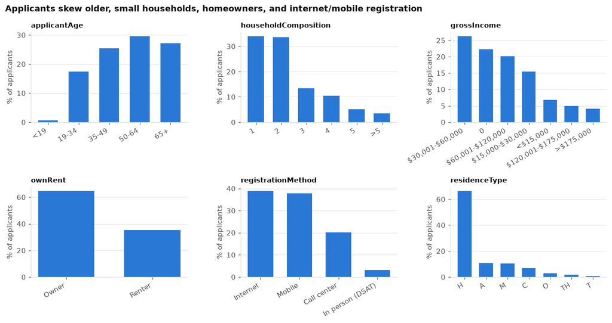

```python
AGE = {0: "<19", 1: "19-34", 2: "35-49", 3: "50-64", 4: "65+"}
CNT = {0: "0", 1: "1", 2: "2", 3: "3", 4: "4", 5: "5", 6: ">5"}
panels = [("applicantAge", AGE), ("householdComposition", CNT), ("grossIncome", None),
          ("ownRent", {"O": "Owner", "R": "Renter"}), ("registrationMethod", {"I": "Internet", "M": "Mobile", "C": "Call center", "D": "In person (DSAT)"}),
          ("residenceType", None)]
fig, axes = plt.subplots(2, 3, figsize=(12, 6.4))
for ax, (col, lab) in zip(axes.ravel(), panels):
    v = clean_df[col].value_counts(normalize=True).mul(100)
    if col in ("applicantAge", "householdComposition"):
        v = v.sort_index()
    else:
        v = v.head(7)
    labels = [str((lab or {}).get(i, i)).replace("$", "\\$") for i in v.index]
    ax.bar(range(len(v)), v.values, color=BLUE, width=0.65)
    ax.set_xticks(range(len(v))); ax.set_xticklabels(labels, rotation=30, ha="right")
    ax.set_title(col, fontsize=10); ax.grid(axis="x", visible=False)
    ax.set_ylabel("% of applicants")
fig.suptitle("Applicants skew older, small households, homeowners, and internet/mobile registration", x=0.01, ha="left", fontweight="bold")
plt.tight_layout(); save_fig("applicant_profile"); plt.show()
```

```python
shares = pd.Series({
    "Applicants aged 50 or older": clean_df["applicantAge"].isin([3, 4]).mean(),
    "Households of 1 or 2 people": clean_df["householdComposition"].isin([1, 2]).mean(),
    "Owners (ownRent = O)": (raw["ownRent"] == "O").mean(),
    "Registered by internet or mobile app (I, M)": raw["registrationMethod"].isin(["I", "M"]).mean(),
}, name="% of all applicants").mul(100).round(1)
shares
```

```
Applicants aged 50 or older                    56.7
Households of 1 or 2 people                    67.6
Owners (ownRent = O)                           64.4
Registered by internet or mobile app (I, M)    76.7
Name: % of all applicants, dtype: float64
```

**So what:** more than half of applicants are 50 or older, most households are 1-2 people, about two-thirds own their home, and over three-quarters registered by internet or mobile app (shares printed below the chart). Our results describe **this** population; they should not be assumed to hold for younger, renter-heavy, or urban disasters.

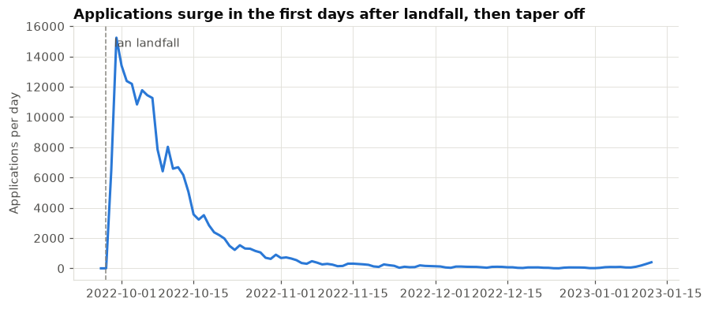

```
Peak day: 2022-09-30 with 15,240 applications; 94% arrived by Oct 31.
```

```python
daily = applied.dt.normalize().value_counts().sort_index()
fig, ax = plt.subplots(figsize=(9, 3.8))
ax.plot(daily.index, daily.values, color=BLUE, lw=2)
ax.set_ylabel("Applications per day"); ax.set_xlabel("")
ax.set_title("Applications surge in the first days after landfall, then taper off")
ax.axvline(pd.Timestamp("2022-09-28"), color=GRAY, lw=1, ls="--")
ax.text(pd.Timestamp("2022-09-28"), daily.max(), "  Ian landfall", color=INK_SOFT, va="top")
save_fig("applications_over_time"); plt.show()
print(f"Peak day: {daily.idxmax().date()} with {daily.max():,} applications; {(daily.loc[:pd.Timestamp('2022-10-31')].sum() / daily.sum()):.0%} arrived by Oct 31.")
```

## 8. How do features relate to eligibility?

Each bar is the **% of applicants in that group who were eligible**; the dashed line is the overall rate. Bars far from the line mark features with real signal. (Groups with fewer than 200 applicants are skipped as unreliable.)

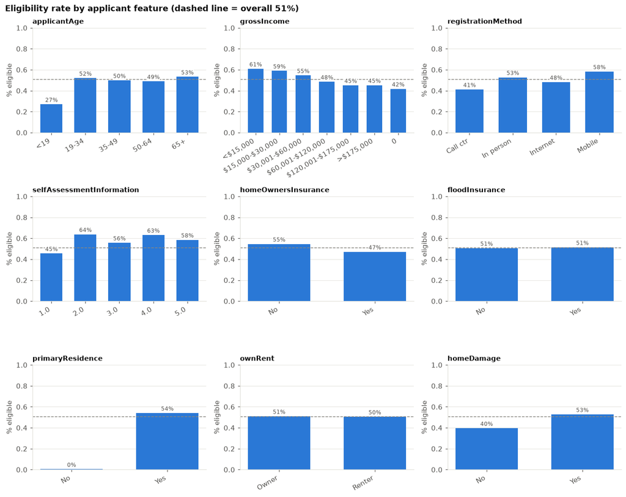

```python
overall = clean_df[TARGET].mean()
YN = {0: "No", 1: "Yes"}

def rate_bar(ax, col, labels=None, order=None):
    g = clean_df.groupby(col, observed=True)[TARGET].agg(["mean", "size"])
    g = g[g["size"] >= 200]
    if order is not None:
        g = g.reindex([o for o in order if o in g.index])
    x = [str((labels or {}).get(i, str(i))).replace("$", "\\$") for i in g.index]
    ax.bar(range(len(g)), g["mean"], color=BLUE, width=0.65)
    for i, m in enumerate(g["mean"]):
        ax.text(i, m + 0.01, f"{m:.0%}", ha="center", va="bottom", fontsize=8, color=INK_SOFT,
                bbox=dict(fc="white", ec="none", pad=0.6))
    ax.axhline(overall, color=GRAY, lw=1, ls="--")
    ax.set_xticks(range(len(g))); ax.set_xticklabels(x, rotation=30, ha="right")
    ax.set_ylim(0, 1.0); ax.set_title(col, fontsize=10); ax.grid(axis="x", visible=False)
    ax.set_ylabel("% eligible")

SELF = {"1": "Minor,\ncan stay", "2": "Lots of\nrepairs", "3": "Major,\ncan't stay", "4": "Destroyed", "5": "Unknown"}
INC = ["<$15,000", "$15,000-$30,000", "$30,001-$60,000", "$60,001-$120,000", "$120,001-$175,000", ">$175,000", "0"]
fig, axes = plt.subplots(3, 3, figsize=(12.5, 10))
rate_bar(axes[0, 0], "applicantAge", AGE)
rate_bar(axes[0, 1], "grossIncome", order=INC)
rate_bar(axes[0, 2], "registrationMethod", {"I": "Internet", "M": "Mobile", "C": "Call ctr", "D": "In person"})
rate_bar(axes[1, 0], "selfAssessmentInformation", SELF)
rate_bar(axes[1, 1], "homeOwnersInsurance", YN)
rate_bar(axes[1, 2], "floodInsurance", YN)
rate_bar(axes[2, 0], "primaryResidence", YN)
rate_bar(axes[2, 1], "ownRent", {"O": "Owner", "R": "Renter"})
rate_bar(axes[2, 2], "homeDamage", YN)
fig.suptitle(f"Eligibility rate by applicant feature (dashed line = overall {overall:.0%})", x=0.01, ha="left", fontweight="bold")
plt.tight_layout(); save_fig("eligibility_by_feature"); plt.show()
```

**So what:**

- **Primary residence is close to a hard rule:** FEMA's IHP only covers a primary home, so non-primary homes are almost never eligible.
- **Owner vs renter barely matters** (both ≈ 51%), which surprised us; we'd have expected a gap.
- **Homeowners insurance is associated with *lower* eligibility.** One possible explanation, to test against FEMA's program rules, is that FEMA covers only losses that insurance does not. The data here does not test that explanation. **Flood insurance** makes little difference.
- **Lower reported income means higher eligibility** (61% for under $15k down to 45% above $175k), except the "$0" group, which is the *lowest* (42%). Since "$0" breaks the ordering, we keep income as an unordered category rather than a number.
- Fairness note for the report: age and income are legitimate FEMA screening inputs, but any future prediction tool must be audited for unequal error rates across groups.

Now the Tier 2 (post-inspection) columns, which are much stronger:

```python
rows = []
for col, lab in [("inspnIssued", "Inspection issued"), ("inspnReturned", "Inspection completed"), ("destroyed", "Home destroyed"),
                 ("verifiedOccupancy", "Occupancy verified"), ("verifiedOwnership", "Ownership verified"), ("floodDamage", "Flood damage recorded")]:
    for v, g in clean_df.groupby(col, observed=True)[TARGET]:
        rows.append({"feature": lab, "value": "Yes" if v == 1 else "No", "applicants": len(g), "% eligible": round(g.mean() * 100, 1)})
pd.DataFrame(rows).pivot(index="feature", columns="value", values="% eligible")
```

| value feature | No | Yes |
| --- | --- | --- |
| Flood damage recorded | 43.9 | 94.0 |
| Home destroyed | 50.0 | 98.7 |
| Inspection completed | 37.8 | 73.3 |
| Inspection issued | 37.8 | 73.3 |
| Occupancy verified | 0.6 | 54.8 |
| Ownership verified | 47.1 | 53.5 |

**So what:** the inspection-stage columns are informative in this file. Applicants whose inspection was completed are 73% eligible versus 38% otherwise. Verified occupancy is 55% eligible versus 0.6% without it, recorded flood damage is 94% eligible versus 44%, and a home recorded as destroyed is 99% eligible versus 50%. Tier 2 should therefore score noticeably higher than Tier 1, at the cost of arriving later in the process. These are associations: the notebook cannot show the order in which fields were recorded.

### Geography and timing

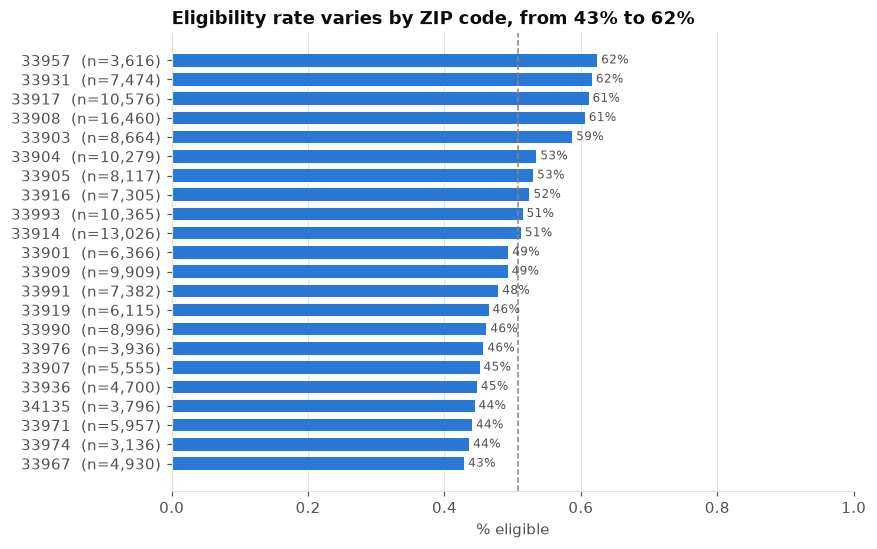

```
22 ZIPs with 3,000+ applicants; eligibility ranges 43% to 62%.
```

```python
z = clean_df.groupby("damagedZipCode", observed=True)[TARGET].agg(["mean", "size"])
z = z[z["size"] >= 3000].sort_values("mean")
fig, ax = plt.subplots(figsize=(8, 5.4))
ax.barh([f"{i}  (n={int(n):,})" for i, n in zip(z.index, z["size"])], z["mean"], color=BLUE, height=0.65)
ax.axvline(overall, color=GRAY, lw=1, ls="--")
for y_, m in enumerate(z["mean"]):
    ax.text(m, y_, f" {m:.0%}", va="center", color=INK_SOFT, fontsize=8)
ax.set_xlim(0, 1); ax.grid(axis="y", visible=False); ax.set_xlabel("% eligible")
ax.set_title(f"Eligibility rate varies by ZIP code, from {z['mean'].min():.0%} to {z['mean'].max():.0%}")
save_fig("eligibility_by_zip"); plt.show()
print(f"{len(z)} ZIPs with 3,000+ applicants; eligibility ranges {z['mean'].min():.0%} to {z['mean'].max():.0%}.")
```

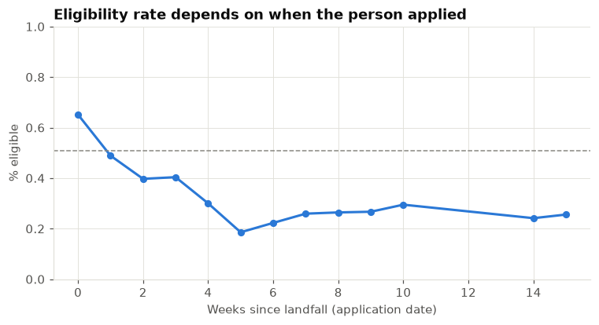

```python
wk = clean_df.assign(week=clean_df["daysSinceLandfall"] // 7).groupby("week")[TARGET].agg(["mean", "size"])
wk = wk[wk["size"] >= 500]
fig, ax = plt.subplots(figsize=(8, 3.8))
ax.plot(wk.index, wk["mean"], color=BLUE, lw=2, marker="o", ms=5)
ax.axhline(overall, color=GRAY, lw=1, ls="--")
ax.set_ylim(0, 1); ax.set_xlabel("Weeks since landfall (application date)"); ax.set_ylabel("% eligible")
ax.set_title("Eligibility rate depends on when the person applied")
save_fig("eligibility_by_week"); plt.show()
```

```python
print(f"Weekly eligibility ranges from {wk['mean'].min():.0%} (week {wk['mean'].idxmin()}) "
      f"to {wk['mean'].max():.0%} (week {wk['mean'].idxmax()}), across {len(wk)} weeks with 500+ applicants")
```

```
Weekly eligibility ranges from 19% (week 5) to 65% (week 0), across 13 weeks with 500+ applicants
```

**So what:** location and timing both carry signal (ZIP eligibility ranges from 43% to 62% across 22 ZIPs with 3,000+ applicants; weekly eligibility falls from 65% in week 0 to 19% in week 5, across 13 weeks with 500+ applicants), so **geography (ZIP / census block) and application date are worth keeping**. They are also where *drift* could bite: because Ian was one storm, findings from this storm should not be assumed to transfer to a different disaster or a different time in the response.

## 9. Correlation analysis

Pearson correlation on numeric and yes/no features (categorical columns are covered by the group rates above). Range −1 to +1; blue = moves *with* eligibility, red = moves *against* it.

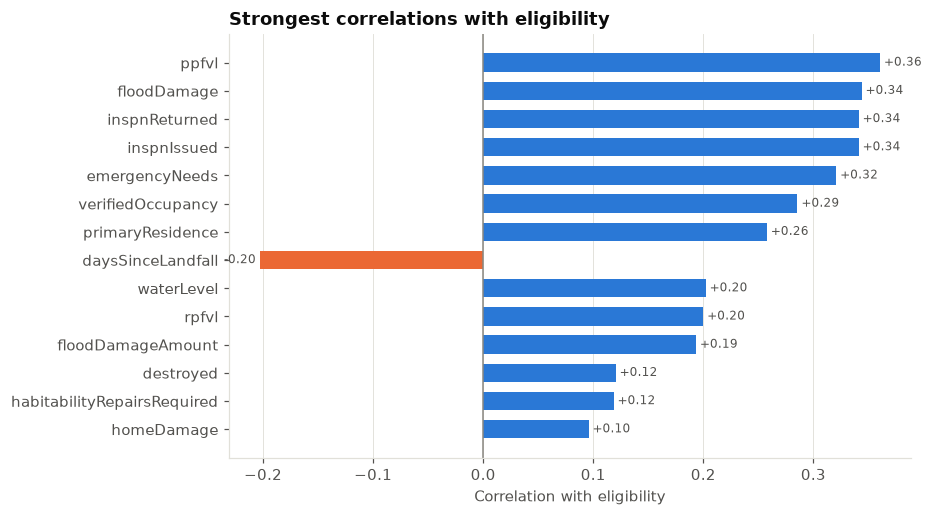

```python
numf = clean_df.select_dtypes("number").astype("float64")
corr = numf.corr()
t = corr[TARGET].drop(TARGET).dropna()
t = t.reindex(t.abs().sort_values(ascending=False).index).head(14).iloc[::-1]

fig, ax = plt.subplots(figsize=(8, 5))
ax.barh(t.index, t.values, color=[BLUE if v > 0 else ORANGE for v in t.values], height=0.65)
ax.axvline(0, color=GRAY, lw=1)
for y_, v in enumerate(t.values):
    ax.text(v, y_, f" {v:+.2f}" if v > 0 else f"{v:+.2f} ", va="center", ha="left" if v > 0 else "right", color=INK_SOFT, fontsize=8)
ax.set_xlabel("Correlation with eligibility"); ax.grid(axis="y", visible=False)
ax.set_title("Strongest correlations with eligibility")
save_fig("correlation_with_target"); plt.show()
```

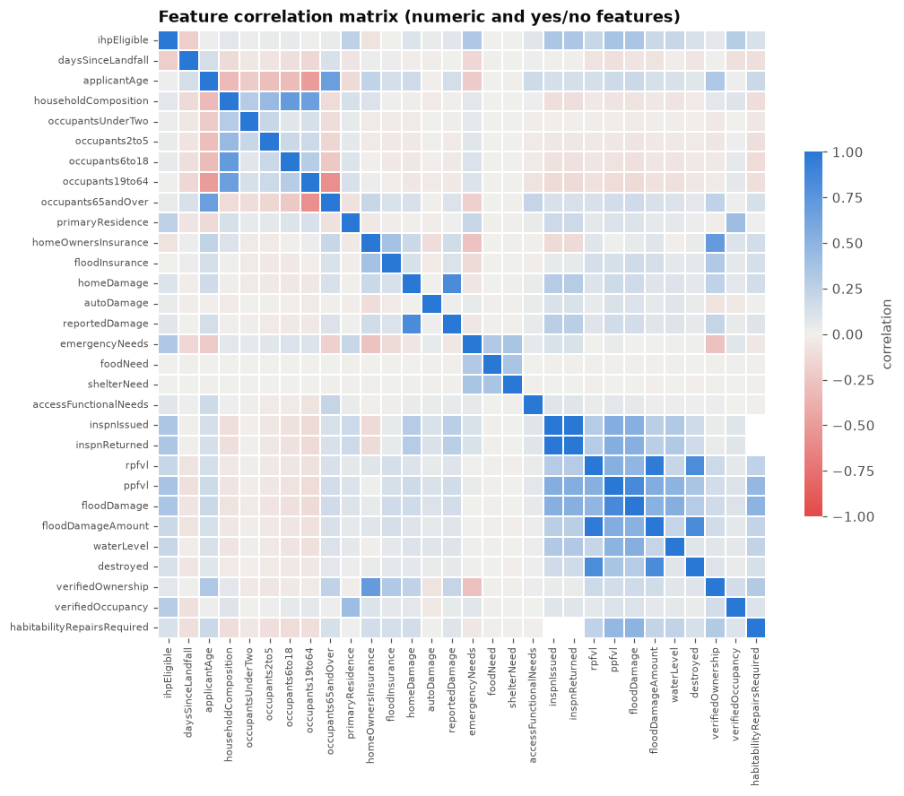

```
Feature pairs that are nearly the same information (|r| > 0.7):
inspnIssued           inspnReturned        1.00
rpfvl                 floodDamageAmount    0.97
ppfvl                 floodDamage          0.85
homeDamage            reportedDamage       0.83
floodDamageAmount     destroyed            0.83
rpfvl                 destroyed            0.83
householdComposition  occupants6to18       0.71
homeOwnersInsurance   verifiedOwnership    0.70
```

```python
div = LinearSegmentedColormap.from_list("div", ["#e34948", "#f0efec", "#2a78d6"])
fig, ax = plt.subplots(figsize=(10, 8))
sns.heatmap(corr, cmap=div, vmin=-1, vmax=1, center=0, square=True, linewidths=0.3, linecolor="white",
            cbar_kws={"shrink": 0.6, "label": "correlation"}, ax=ax)
ax.set_title("Feature correlation matrix (numeric and yes/no features)")
ax.tick_params(labelsize=7); ax.grid(False)
save_fig("correlation_matrix"); plt.show()

upper = corr.where(np.triu(np.ones(corr.shape), 1).astype(bool)).stack()
strong = upper[upper.abs() > 0.7].sort_values(key=abs, ascending=False)
print("Feature pairs that are nearly the same information (|r| > 0.7):")
print(strong.round(2).to_string() if len(strong) else "none")
```

**So what:** no single numeric feature correlates strongly with eligibility, but the strongest are inspection-stage amounts: FEMA-verified personal property loss (`ppfvl`, +0.36), recorded flood damage (+0.34), and inspection issued or returned (+0.34). Among application-time columns, emergency needs (+0.32) and primary residence (+0.26) lead. This matches the leakage check: prediction has to combine features. Eight pairs are near-duplicates (|r| > 0.7). The clearest are inspection issued vs returned (1.00), real-property loss vs flood-damage amount (0.97), and home damage vs reported damage (0.83). We will drop one of each pair for linear methods and let tree-based methods handle the rest.

## 10. Preliminary checks: what do the awards look like?

A quick descriptive check on the outcome before we describe the features. Nothing is fit or scored here.

**First, what does an award look like?** If awards cluster on a few fixed amounts, eligibility may be driven by simple rules.

```python
el = raw[raw[TARGET]]
top = el["ihpAmount"].value_counts().head(5)
tbl = pd.DataFrame({"applicants": top, "% of all eligible": (top / len(el) * 100).round(1)})
tbl.index = [f"${v:,.0f}" for v in tbl.index]
tbl.index.name = "award amount"
print(tbl.to_string())

need = raw.groupby("emergencyNeeds")[TARGET].agg(["mean", "size"])
print("\n% eligible by 'reported emergency needs':")
print((need["mean"] * 100).round(1).rename({False: "No", True: "Yes"}).to_string())
```

```
              applicants  % of all eligible
award amount
$700               45192               45.8
$1,000             12542               12.7
$300                8129                8.2
$3,602              3613                3.7
$2,982              2653                2.7

% eligible by 'reported emergency needs':
emergencyNeeds
No     33.6
Yes    65.7
```

```python
el = raw[raw[TARGET]].copy()
el["emergency"] = el["emergencyNeeds"].map({True: "emergency needs: yes", False: "emergency needs: no"}).fillna("missing")
el["at_700"] = el["ihpAmount"] == 700
print(pd.crosstab(el["emergency"], el["at_700"], margins=True).rename(columns={True: "at $700", False: "other amount"}))
print(pd.crosstab(el["emergency"], el["at_700"], normalize="index").mul(100).round(1).rename(columns={True: "% at $700", False: "% other amount"}))
```

```
at_700                other amount  at $700    All
emergency
emergency needs: no          22822     7654  30476
emergency needs: yes         30633    37538  68171
missing                          1        0      1
All                          53456    45192  98648
at_700                % other amount  % at $700
emergency
emergency needs: no             74.9       25.1
emergency needs: yes            44.9       55.1
missing                        100.0        0.0
```

**So what:** nearly half of all eligible applicants received *exactly $700*, and reporting emergency needs takes eligibility from about a third to about two-thirds. The table above shows that $700 is more common among applicants who reported emergency needs (55% of them vs. 25% of those who did not), but it is not limited to them: a quarter of eligible applicants without reported needs also received $700. So the $700 award is linked to the emergency-needs answer, but it is not a pure flat emergency-needs payment. This is a hypothesis to confirm against FEMA's program documentation.

**Second, is the location field safe?** `currentLocation` records where the applicant is staying. Some values are places people end up *after* receiving help:

```python
loc = raw.groupby("currentLocation")[TARGET].agg(["mean", "size"])
loc = loc[loc["size"] >= 250].sort_values("mean", ascending=False)
LOC = {"MHU": "FEMA-provided unit", "R": "New temporary rental", "RVT": "RV | camper", "P": "Purchased new home",
       "PRU": "New permanent rental", "F": "Family | friends", "D": "My home", "H": "Hotel | motel", "SR": "Secondary residence",
       "NH": "Homeless", "S": "Mass shelter", "E": "Place of employment", "C": "My vehicle", "T": "Tent", "CH": "Church"}
loc.index = [f"{LOC.get(i, i)} ({i})" for i in loc.index]
loc["% eligible"] = (loc["mean"] * 100).round(1)
print(loc[["% eligible", "size"]].rename(columns={"size": "applicants"}).to_string())
```

```
                            % eligible  applicants
FEMA-provided unit (MHU)          98.6         277
New temporary rental (R)          87.1        5375
RV | camper (RVT)                 81.6        1770
Purchased new home (P)            79.0         381
New permanent rental (PRU)        77.4        1093
Place of employment (E)           73.1         360
Family | friends (F)              69.7       31466
My vehicle (C)                    59.8         799
My home (D)                       46.7      131930
Mass shelter (S)                  40.3         789
Secondary residence (SR)          36.3        7173
Homeless (NH)                     36.0        1487
Hotel | motel (H)                 29.1       11229
```

**So what:** "FEMA-provided unit" is 99% eligible and "new rental" 87%. A plausible reading is that these describe where applicants ended up *after* aid, not before it. The data here does not test that reading. The statement that the field can be updated after registration comes from FEMA's field definition, not from this data, and should be checked against that documentation. We therefore moved `currentLocation` **out of Tier 1** (it now sits in the later-stage Tier 2).

## 11. Key findings, challenges, and limitations

```python
best_legit = assoc[assoc["role"].isin(["application", "inspection"])]["cramers_v"]
best_leak = assoc[assoc["role"] == "leakage"]["cramers_v"].max()
print("KEY NUMBERS")
print(f"  Rows | columns .................. {raw.shape[0]:,} | {raw.shape[1]}")
print(f"  Target balance .................. {raw[TARGET].mean():.1%} eligible")
print(f"  Leakage columns ................. {len(LEAKAGE)} of {raw.shape[1]} (strongest link to eligibility: V = {best_leak:.2f})")
print(f"  Usable features ................. {len(APPLICATION_FEATURES)} application-time + {len(INSPECTION_FEATURES)} inspection-time")
print(f"  Strongest legitimate column ..... V = {best_legit.max():.2f}  ({best_legit.idxmax()})")
print(f"  Constant | ID columns ........... {len(constant)}")
print(f"  Duplicate-looking rows .......... {dups:,}")
```

```
KEY NUMBERS
  Rows | columns .................. 194,482 | 100
  Target balance .................. 50.7% eligible
  Leakage columns ................. 43 of 100 (strongest link to eligibility: V = 1.00)
  Usable features ................. 26 application-time + 14 inspection-time
  Strongest legitimate column ..... V = 0.46  (habitabilityRepairsRequired)
  Constant | ID columns ........... 14
  Duplicate-looking rows .......... 407
```

**Findings**

1. The data meets the project requirements: 194,482 rows, 100 columns, mixed numeric and categorical.
2. **Target `ihpEligible` is nearly balanced** (50.7% eligible), so accuracy is a meaningful measure.
3. **Leakage is the central risk:** 43 of 100 columns are outcomes of the decision. `ihpAmount` matches eligibility exactly (V = 1.00), and the sub-program amounts and referral fields are strongly linked. They are isolated in the column roles section (Section 4) so no one uses them by accident.
4. **Application-time features are individually weak** (strongest V about 0.32, from emergency needs). Inspection-stage features are stronger (strongest about 0.46, largely because whether they were recorded is informative). Emergency needs, food need, primary residence, and application timing carry the most application-time signal.
5. **Inspection-stage data is informative in this file:** all 14 Tier 2 columns vary. The largest gaps come from `habitabilityRepairsRequired`, `highWaterLocation`, and `renterDamageLevel`, which are mostly blank. Tier 2 should be assessed in Milestone 2, not dropped.
6. Nearly half of all awards are exactly $700. That award is more common among applicants reporting emergency needs (55% vs. 25%), but not limited to them, so it is a hypothesis to confirm with FEMA documentation.

**Challenges and limitations (for the report)**

- *Rule-driven outcome:* because eligibility partly follows FEMA's own screening rules, a strong pattern does not mean the data captures need. It should support caseworkers, not replace them.
- *Scope:* one disaster, one county: results describe Ian in Lee County and may not generalize.
- *Selection:* only **valid registrants** are included; we cannot say anything about invalid applications.
- *Label meaning:* "not eligible" bundles many reasons (insurance, no documents, withdrew, duplicate, never referred).
- *Source noise:* operational data with human-entry error (city spellings, out-of-county addresses, two applications dated before the declaration).
- *Structural missingness* in need columns: `shelterNeed` is 82% blank and `foodNeed` 52% blank.
- *Informative blanks:* a blank `utilitiesOut` is 99.9% eligible (Section 5b). It is held out of the features until verified, since it may be a field completed after the decision.
- *High-cardinality geography* (ZIP, census block) needs careful encoding to avoid overfitting.